# US Economic Productivity and Minimum Wage

## Decades

### Decades GDP Projected: Change in minimum wage values by decade for raw minimum wage and GDP Projected minimum wage

```r
# this portion will look at changes in raw minimum wage and GDP Projected minimum wage from the first year in a decade to the last year in the decade for each decade starting with the 1950s and going through the 2010s, with 2018 as the end value for this decade (minimum wage has not changed since 2018)
decades_GDPadj <- main_dataset %>%
  select(year, raw_min_wage, min_wage_2018_adjusted) %>% # only looking at these columns
  mutate(year = as.character(year)) %>%
  filter(year == "2018" | str_detect(year, "0$") | str_detect(year, "9$") & year != "1949") %>% # only want beginning and end decade years, including 2018 and excluding the 1940s
  mutate(year = str_replace(year, "2018", "2019")) %>% # change 2018 to 2019 so that we can use str formulas more easily
  mutate(decade_change = raw_min_wage - lag(raw_min_wage, default = first(raw_min_wage))) %>% # create calculation to find change in raw minimum wage over the decade
  mutate(decade_change_adj = min_wage_2018_adjusted - lag(min_wage_2018_adjusted, default = first(min_wage_2018_adjusted))) %>% # create calculation to find change in adjusted minimum wage over the decade
  mutate(beg_decade_wage = ifelse(!str_detect(year, "0$"), lag(raw_min_wage), 0)) %>% # if the year does not end in 0, take the prior value, this is because when we take percentage changes, we compare to starting value
  mutate(beg_decade_wage_adj = ifelse(!str_detect(year, "0$"), lag(min_wage_2018_adjusted), 0)) %>%
  filter(str_detect(year, "9$")) %>% # only care about changes for end of decade
  mutate(decade = str_replace(year, "9$", "0s")) %>% # rename values to embody whole decade
  select(decade, decade_change, decade_change_adj, beg_decade_wage, beg_decade_wage_adj) # select and order columns

# make the rows currency values for the table
decades_GDPadj$decade_change <- currency(decades_GDPadj$decade_change, digits = 2L)
decades_GDPadj$beg_decade_wage <- currency(decades_GDPadj$beg_decade_wage, digits = 2L)
decades_GDPadj$beg_decade_wage_adj <- currency(decades_GDPadj$beg_decade_wage_adj, digits = 2L)
decades_GDPadj$decade_change_adj <- currency(decades_GDPadj$decade_change_adj, digits = 2L)

raw_wage_footnote <- "Raw minimum wage in the first year of the decade"
adj_wage_footnote <- "GDP Projected Minimum Wage in the first year of the decade"

decades_footnotes = c(raw_wage_footnote,
              adj_wage_footnote)

decades_GDPadj_table <- decades_GDPadj %>%
  kable(col.names = c("Decade",
                      "Raw Decade Change",
                      "GDP Projected Decade Change",
                      "Raw Minimum Wage[note]",
                      "GDP Projected Minimum Wage[note]"),
      align = "cccc",
      caption = "Changes in Raw and GDP Projected Minimum Wage by Decade",
      format.args = list(big.mark = ","),
      digits = c(0, 2, 2)) %>% # specify decimal points
  kable_paper(font_size = 12,
              html_font = "Georgia",
              full_width = T) %>% # allows for table to print to pdf more cleanly
  kable_styling(latex_options = "striped") %>%
  row_spec(0, bold = T, color ="seagreen", font_size = 15) %>% #Add styling to header
  column_spec(1, bold = T) %>%
  add_footnote(decades_footnotes)

decades_GDPadj_table
```

Changes in Raw and GDP Projected Minimum Wage by Decade

| Decade | Raw Decade Change | GDP Projected Decade Change | Raw Minimum Wage<sup>a</sup> | GDP Projected Minimum Wage<sup>b</sup> |
| --- | --- | --- | --- | --- |
| 1950s | $0.25 | $0.80 | $0.75 | $3.78 |
| 1960s | $0.60 | $1.12 | $1.00 | $4.65 |
| 1970s | $1.30 | $5.30 | $1.60 | $6.10 |
| 1980s | $0.25 | $6.53 | $3.10 | $12.94 |
| 1990s | $1.35 | $5.64 | $3.80 | $20.52 |
| 2000s | $2.10 | $6.66 | $5.15 | $27.05 |
| 2010s | $0.00 | $5.19 | $7.25 | $34.26 |

<sup>a</sup> Raw minimum wage in the first year of the decade  
<sup>b</sup> GDP Projected Minimum Wage in the first year of the decade

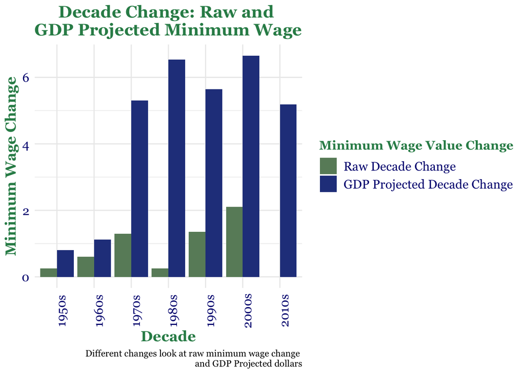

```r
decades_GDPadj_graph <- decades_GDPadj %>%
  mutate(decade_change = as.numeric(decade_change), # change to numeric so that we are able to pivot
         decade_change_adj = as.numeric(decade_change_adj)) %>%
  pivot_longer(cols = 2:3,
               names_to = "type",
               values_to = "change_amount") %>% # pivot since we will be showing these values as different fill colors on our graph
  ggplot() +
  geom_bar(aes(x = decade, y = change_amount, fill = type), stat = "identity", position = 'dodge') +
  scale_fill_manual(values = c("decade_change" = "darkseagreen4", "decade_change_adj" = "royalblue4"),
                    labels = c("Raw Decade Change", "GDP Projected Decade Change" )) + # change colors to match our theme
  labs(title = "Decade Change: Raw and \nGDP Projected Minimum Wage", # title graph
       y = "Minimum Wage Change", # label y axis
       x = "Decade", # label x axis
       caption = "Different changes look at raw minimum wage change \nand GDP Projected dollars",
       fill = "Minimum Wage Value Change") +
  wage_theme +
  theme(plot.title = element_text(hjust = 0.5)) # center the title

decades_GDPadj_graph # view the graph
```

#### Decades GDP Projected Interpretation:

We see the trend for raw minimum wage of steadily increasing until the steep drop off in the 1980s. This appears to be recovered in the 1990s and 2000s, but drops to 0 in the 2010s, since there was no minimum wage increase this decade.

This chart shows the side by side comparison of how minimum wage actually changed decade to decade (raw) versus how it should have changed to keep up with GDP Projected levels. While none of the decades come close to measuring up to the adjusted level, the 1950s through 1970s raw minimum wage changes show similar trends in terms of direction and comparative increases to the adjusted value. However, this pattern is thrown off in 1980s, with a significant decline offsetting the GDP increase. Hopes for recovery from this decline are seen through the 1990s and 2000s, but are squashed in the 2010s when the decade change falls to 0 - a decrease that is much more significant than the GDP adjusted decrease in the decade.

### Decades Purchasing Power: Change in minimum wage values by decade for raw minimum wage and purchasing power of minimum wage

```r
# this portion will look at changes in raw minimum wage and purchasing power of minimum wage from the first year in a decade to the last year in the decade for each decade starting with the 1950s and going through the 2010s, with 2018 as the end value for this decade (minimum wage has not changed since 2018)
decades_PurchPower <- main_dataset %>%
  select(year, raw_min_wage, min_wage_purchasing_power) %>% # only looking at these columns
  mutate(year = as.character(year)) %>%
  filter(year == "2018" | str_detect(year, "0$") | str_detect(year, "9$") & year != "1949") %>% # only want beginning and end decade years, including 2018 and excluding the 1940s
  mutate(year = str_replace(year, "2018", "2019")) %>% # change 2018 to 2019 so that we can use str formulas more easily
  mutate(decade_change = raw_min_wage - lag(raw_min_wage, default = first(raw_min_wage))) %>% # create calculation to find change in raw minimum wage over the decade
  mutate(decade_change_pp = min_wage_purchasing_power - lag(min_wage_purchasing_power, default = first(min_wage_purchasing_power))) %>% # create calculation to find change in purchasing power of minimum wage over the decade
  mutate(beg_decade_wage = ifelse(!str_detect(year, "0$"), lag(raw_min_wage), 0)) %>% # if the year does not end in 0, take the prior value, this is because when we take percentage changes, we compare to starting value
  mutate(beg_decade_wage_pp = ifelse(!str_detect(year, "0$"), lag(min_wage_purchasing_power), 0)) %>%
  filter(str_detect(year, "9$")) %>% # only care about changes for end of decade
  mutate(decade = str_replace(year, "9$", "0s")) %>% # rename values to embody whole decade
  select(decade, decade_change, decade_change_pp, beg_decade_wage, beg_decade_wage_pp) # select and order columns

# make the rows currency values for the table
decades_PurchPower$decade_change <- currency(decades_PurchPower$decade_change, digits = 2L)
decades_PurchPower$beg_decade_wage <- currency(decades_PurchPower$beg_decade_wage, digits = 2L)
decades_PurchPower$beg_decade_wage_pp <- currency(decades_PurchPower$beg_decade_wage_pp, digits = 2L)
decades_PurchPower$decade_change_pp <- currency(decades_PurchPower$decade_change_pp, digits = 2L)

raw_wage_footnote <- "Raw minimum wage in the first year of the decade"
pp_wage_footnote <- "Purchasing power of minimum wage in the first year of the decade"

decades_footnotes_1 = c(raw_wage_footnote,
              pp_wage_footnote)

decades_PurchPower_table <- decades_PurchPower %>%
  kable(col.names = c("Decade",
                      "Raw Decade Change",
                      "Purchasing Power Decade Change",
                      "Raw Minimum Wage[note]",
                      "Purchasing Power of Minimum Wage[note]"),
      align = "cccc",
      caption = "Changes in Raw and Purchasing Power of Minimum Wage by Decade",
      format.args = list(big.mark = ","),
      digits = c(0, 2, 2)) %>% # specify decimal points
  kable_paper(font_size = 12,
              html_font = "Georgia",
              full_width = T) %>% # allows for table to print to pdf more cleanly
  kable_styling(latex_options = "striped") %>%
  row_spec(0, bold = T, color ="seagreen", font_size = 15) %>% #Add styling to header
  column_spec(1, bold = T) %>%
  add_footnote(decades_footnotes_1)

decades_PurchPower_table
```

Changes in Raw and Purchasing Power of Minimum Wage by Decade

| Decade | Raw Decade Change | Purchasing Power Decade Change | Raw Minimum Wage<sup>a</sup> | Purchasing Power of Minimum Wage<sup>b</sup> |
| --- | --- | --- | --- | --- |
| 1950s | $0.25 | $0.79 | $0.75 | $7.83 |
| 1960s | $0.60 | $2.46 | $1.00 | $8.49 |
| 1970s | $1.30 | $-0.31 | $1.60 | $10.34 |
| 1980s | $0.25 | $-2.66 | $3.10 | $9.45 |
| 1990s | $1.35 | $0.46 | $3.80 | $7.30 |
| 2000s | $2.10 | $0.97 | $5.15 | $7.51 |
| 2010s | $0.00 | $-1.10 | $7.25 | $8.35 |

<sup>a</sup> Raw minimum wage in the first year of the decade  
<sup>b</sup> Purchasing power of minimum wage in the first year of the decade

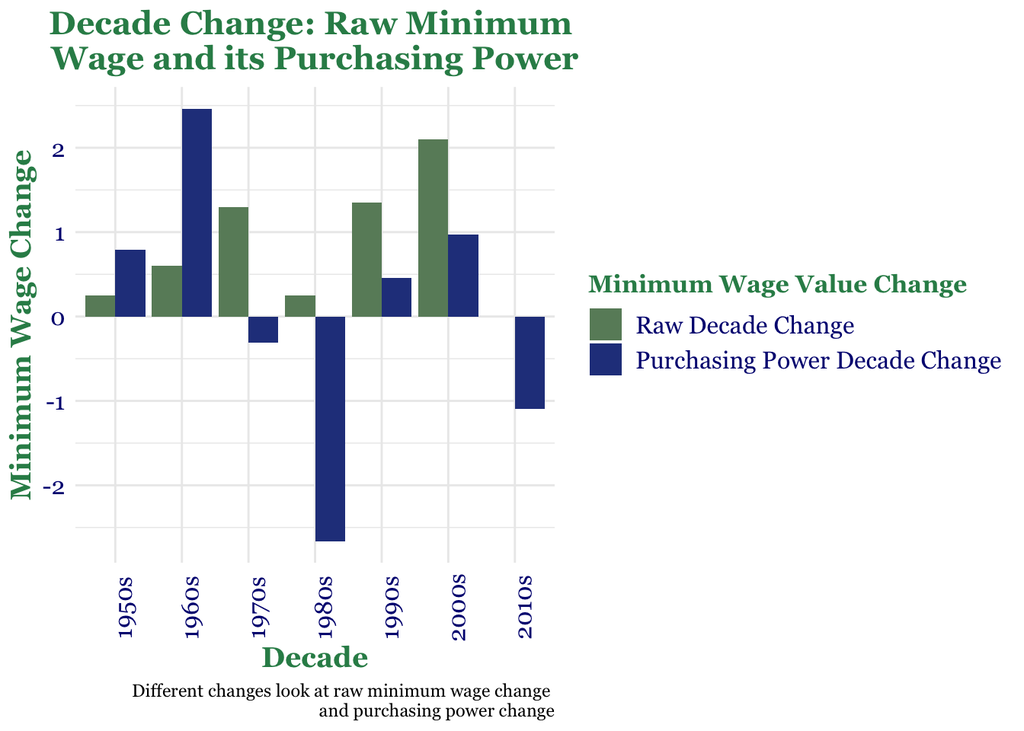

```r
decades_PurchPower_graph <- decades_PurchPower %>%
  mutate(decade_change = as.numeric(decade_change), # change to numeric so that we are able to pivot
         decade_change_pp = as.numeric(decade_change_pp)) %>%
  pivot_longer(cols = 2:3,
               names_to = "type",
               values_to = "change_amount") %>% # pivot since we will be showing these values as different fill colors on our graph
  ggplot() +
  geom_bar(aes(x = decade, y = change_amount, fill = type), stat = "identity", position = 'dodge') +
  scale_fill_manual(values = c("decade_change" = "darkseagreen4", "decade_change_pp" = "royalblue4"),
                    labels = c("Raw Decade Change", "Purchasing Power Decade Change" )) + # change colors to match our theme
  labs(title = "Decade Change: Raw Minimum \nWage and its Purchasing Power", # title graph
       y = "Minimum Wage Change", # label y axis
       x = "Decade", # label x axis
       caption = "Different changes look at raw minimum wage change \nand purchasing power change",
       fill = "Minimum Wage Value Change") +
  wage_theme +
  theme(plot.title = element_text(hjust = 0.5)) # center the title

decades_PurchPower_graph # view the graph
```

#### Decades Purchasing Power Interpretation:

The interpretation for raw decade change is the same as in the analysis above. The changes in purchasing power of minimum wage demonstrate that purchasing power has faced significant decreases in the 1980s and the 2010s, the two decades where minimum wage was increased either once or not at all.

### Decades All: Change in minimum wage values by decade for raw minimum wage, purchasing power of minimum wage, and GDP Projected minimum wage

```r
decades_all <- main_dataset %>%
  select(year, raw_min_wage, min_wage_purchasing_power, min_wage_2018_adjusted) %>% # only looking at these columns
  mutate(year = as.character(year)) %>%
  filter(year == "2018" | str_detect(year, "0$") | str_detect(year, "9$") & year != "1949") %>% # only want beginning and end decade years, including 2018 and excluding the 1940s
  mutate(year = str_replace(year, "2018", "2019")) %>% # change 2018 to 2019 so that we can use str formulas more easily
  mutate(decade_change = raw_min_wage - lag(raw_min_wage, default = first(raw_min_wage))) %>% # create calculation to find change in raw minimum wage over the decade
  mutate(decade_change_pp = min_wage_purchasing_power - lag(min_wage_purchasing_power, default = first(min_wage_purchasing_power))) %>% # create calculation to find change in purchasing power of minimum wage over the decade
  mutate(decade_change_adj = min_wage_2018_adjusted - lag(min_wage_2018_adjusted, default = first(min_wage_2018_adjusted))) %>% # create calculation to find change in purchasing power of minimum wage over the decade
  mutate(beg_decade_wage = ifelse(!str_detect(year, "0$"), lag(raw_min_wage), 0)) %>% # if the year does not end in 0, take the prior value, this is because when we take percentage changes, we compare to starting value
  mutate(beg_decade_wage_pp = ifelse(!str_detect(year, "0$"), lag(min_wage_purchasing_power), 0)) %>%
  mutate(beg_decade_wage_adj = ifelse(!str_detect(year, "0$"), lag(min_wage_2018_adjusted), 0)) %>%
  filter(str_detect(year, "9$")) %>% # only care about changes for end of decade
  mutate(decade = str_replace(year, "9$", "0s")) %>% # rename values to embody whole decade
  select(decade, decade_change, decade_change_pp, decade_change_adj, beg_decade_wage, beg_decade_wage_pp, beg_decade_wage_adj) # select and order columns

# make the rows currency values for the table
decades_all$decade_change <- currency(decades_all$decade_change, digits = 2L)
decades_all$beg_decade_wage <- currency(decades_all$beg_decade_wage, digits = 2L)
decades_all$beg_decade_wage_pp <- currency(decades_all$beg_decade_wage_pp, digits = 2L)
decades_all$decade_change_pp <- currency(decades_all$decade_change_pp, digits = 2L)
decades_all$beg_decade_wage_adj <- currency(decades_all$beg_decade_wage_adj, digits = 2L)
decades_all$decade_change_adj <- currency(decades_all$decade_change_adj, digits = 2L)

raw_wage_footnote <- "Raw minimum wage in the first year of the decade"
pp_wage_footnote <- "Purchasing power of minimum wage in the first year of the decade"
adj_wage_footnote <- "GDP Projected minimum wage in the first year of the decade"

decades_footnotes_2 = c(raw_wage_footnote,
              pp_wage_footnote,
              adj_wage_footnote)

decades_table_2 <- decades_all %>%
  kable(col.names = c("Decade",
                      "Raw Decade Change",
                      "Purchasing Power Decade Change",
                      "GDP Projected Decade Change",
                      "Raw Minimum Wage[note]",
                      "Purchasing Power of Minimum Wage[note]",
                      "GDP Projected Minimum Wage[note]"),
      align = "cccc",
      caption = "Changes in Raw, GDP Projected, and Purchasing Power of Minimum Wage by Decade",
      format.args = list(big.mark = ","),
      digits = c(0, 2, 2)) %>% # specify decimal points
  kable_paper(font_size = 12,
              html_font = "Georgia",
              full_width = T) %>% # allows for table to print to pdf more cleanly
  kable_styling(latex_options = "striped") %>%
  row_spec(0, bold = T, color ="seagreen", font_size = 15) %>% #Add styling to header
  column_spec(1, bold = T) %>%
  add_footnote(decades_footnotes_2)

decades_table_2
```

Changes in Raw, GDP Projected, and Purchasing Power of Minimum Wage by Decade

| Decade | Raw Decade Change | Purchasing Power Decade Change | GDP Projected Decade Change | Raw Minimum Wage<sup>a</sup> | Purchasing Power of Minimum Wage<sup>b</sup> | GDP Projected Minimum Wage<sup>c</sup> |
| --- | --- | --- | --- | --- | --- | --- |
| 1950s | $0.25 | $0.79 | $0.80 | $0.75 | $7.83 | $3.78 |
| 1960s | $0.60 | $2.46 | $1.12 | $1.00 | $8.49 | $4.65 |
| 1970s | $1.30 | $-0.31 | $5.30 | $1.60 | $10.34 | $6.10 |
| 1980s | $0.25 | $-2.66 | $6.53 | $3.10 | $9.45 | $12.94 |
| 1990s | $1.35 | $0.46 | $5.64 | $3.80 | $7.30 | $20.52 |
| 2000s | $2.10 | $0.97 | $6.66 | $5.15 | $7.51 | $27.05 |
| 2010s | $0.00 | $-1.10 | $5.19 | $7.25 | $8.35 | $34.26 |

<sup>a</sup> Raw minimum wage in the first year of the decade  
<sup>b</sup> Purchasing power of minimum wage in the first year of the decade  
<sup>c</sup> GDP Projected minimum wage in the first year of the decade

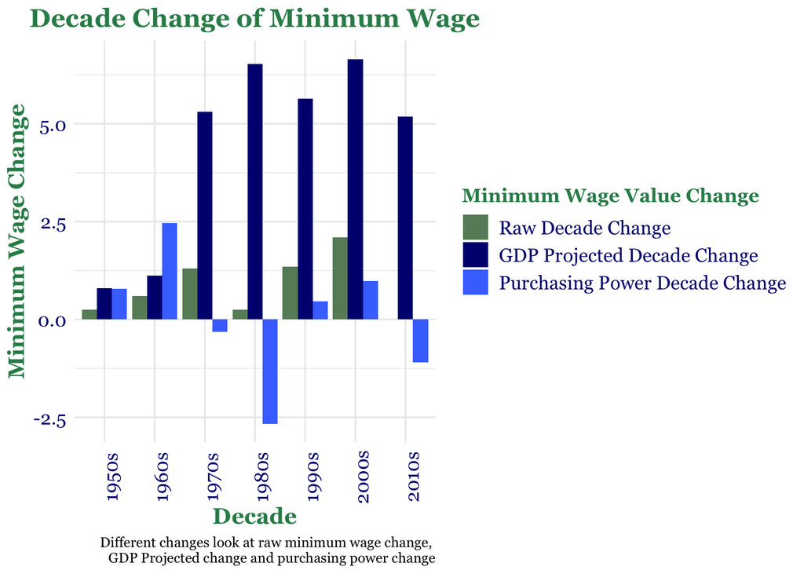

```r
decades_graph_2 <- decades_all %>%
  mutate(decade_change = as.numeric(decade_change), # change to numeric so that we are able to pivot
         decade_change_pp = as.numeric(decade_change_pp),
         decade_change_adj = as.numeric(decade_change_adj)) %>%
  pivot_longer(cols = 2:4,
               names_to = "type",
               values_to = "change_amount") %>% # pivot since we will be showing these values as different fill colors on our graph
  ggplot() +
  geom_bar(aes(x = decade, y = change_amount, fill = type), stat = "identity", position = 'dodge') +
  scale_fill_manual(values = c("decade_change" = "darkseagreen4",
                               "decade_change_pp" = "royalblue1",
                               "decade_change_adj" = "navyblue"),
                    labels = c("Raw Decade Change", "GDP Projected Decade Change", "Purchasing Power Decade Change")) + # change colors to match our theme and ensure legend labels are helpful
  labs(title = "Decade Change of Minimum Wage", # title graph
       y = "Minimum Wage Change", # label y axis
       x = "Decade", # label x axis
       caption = "Different changes look at raw minimum wage change, \nGDP Projected change and purchasing power change",
       fill = "Minimum Wage Value Change") +
  wage_theme +
  theme(plot.title = element_text(hjust = 0.5)) # center the title

decades_graph_2 # view the graph
```

#### Decades All Interpretation:

Through examining this graph, we can clearly see how the relationship between raw minimum wage, GDP Projected minimum wage, and purchasing power of minimum wage changed decade to decade.

## Wage calculations

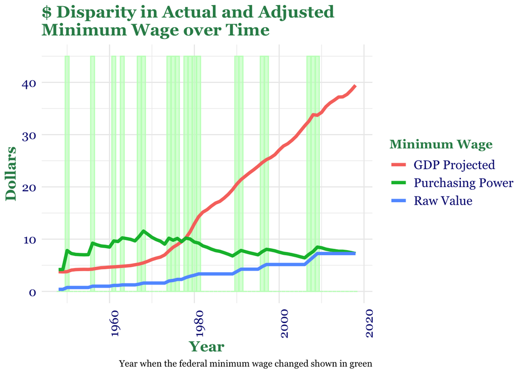

```r
wage_values_graph <-
  ggplot() +
    geom_bar(data = main_dataset, aes(x = year, y = wage_change), alpha = .6, stat = "identity", fill = "darkseagreen1", color = "darkseagreen1") + # shows years that minimum wage changed in green with an alpha to make the bars transparent
  geom_path(data = main_dataset_final, aes(x = year, y = Dollars, color = Type), size = 1.5) + # shows values from the "Type" column of raw_min_wage, min_wage_2018_adjusted, and min_wage_purchasing_power
  labs(title = "$ Disparity in Actual and Adjusted \nMinimum Wage over Time", # title graph
       y = "Dollars", # label y axis
       x = "Year", # label x axis
       caption = "Year when the federal minimum wage changed shown in green") + # add caption to specify what the bar graph is
  scale_color_discrete(name="Minimum Wage", # label color legend
    labels=c( # change the legend text values
      "GDP Projected",
      "Purchasing Power",
      "Raw Value")) + # add in our theme (created above)
  theme(plot.title = element_text(hjust = 0.5)) + # center the title
  wage_theme

wage_values_graph # view the graph
```

### GDP Projected Versus Raw Value:

The graph shows the steady shallow slope of the raw value of minimum wage over time, ending in a value of $7.25 in 2018. On the other hand, the GDP Projected line, which calculates minimum wage in 2018 dollars adjusted for GDP, shows a much steeper slope. The slope particularly appears to begin its sharp increase in the late 1970s and really takes off around 1981 (the first year of the Reagan administration), ending with a value of $39.45. The gap between these lines demonstrates the amount that wage has failed to increase proportionately with GDP, or net productivity. In terms of informing policy, a GDP adjusted minimum wage of almost $40 makes the “Fight for 15” appear much less radical.

### Purchasing Power Versus Raw Value:

These metrics highlight that minimum wage over time has failed to keep pace with the economic factors of productivity and purchasing power.

### Years with Changes in Federal Minimum Wage:

Another informative component of the graph is the green bars, which represent years when federal minimum wage increased. From this analysis, we can see that the longest periods where minimum wage went unchanged were from 1982-1989 (Reagan), 1997-2007 (Clinton and Bush), and from 2009-present (Obama, Trump, Biden). Further, 1974-1981 had almost annual increases in federal minimum wage. Though the increases do not appear to have kept pace with the increasing GDP those years, the increases prevented the gap from widening as much as it would have if the wage had flat-lined. The context provided from viewing historical increases in minimum wage make it clear that the unchanged federal minimum wage from 2009-2018 (and, indeed, to 2021), is an uncommonly long duration. Further, while raw minimum wage has plateaued, GDP Projected values continue to increase sharply and steadily.

## Snapshot of Minimum Wage Increases

While reflecting on patterns of minimum wage value and increases, it can be helpful to take a snapshot of how minimum wage looks in years in which Congress voted to increase that value. Alongside the raw minimum wage value, the purchasing power of minimum wage, and a productivity-increased minimum wage value, we wanted to include which president oversaw the increase in minimum wage and the number of years since the previous change.

We wanted to add these values in context because it allows for observers to see more political context when thinking about minimum wage changes and, in particular, to emphasize the lack of steady and regular increases in the minimum wage in the second half of the 20th Century and the beginning of the 21st Century.

It is exactly this lack of increases in the minimum wage that has contributed to the lessening purchasing power of minimum wage, which contributes to many economic issues in the country such as widening inequality.

Click to view the tidying of the presidents dataset:

```r
# Add in president data pulled in earlier
# This helps us to provide some analysis of what administrations increased wages for context, referenced in our interpretation of our chart

wage_with_pres <-
  left_join(main_dataset, presidents) %>%
  fill(president, .direction = "up") %>%  # ensure that all years have president values
  filter(!duplicated(year, fromLast = T))
```

Click here to view the table preparation and creation:

```r
# Create table data; we want to narrow down
table_dataset <-
  left_join(wage_with_pres, min_wage_dataset) %>%
  filter(wage_change == 45,
         year >= 1948) %>%
  select(year,
         president,
         raw_min_wage,
         min_wage_purchasing_power,
         min_wage_2018_adjusted) %>%
  mutate("Number of Years Since Last Change" = year - lag(year, default = first(year)), # calculate how long it has been since the last increase in minimum wage
         year = as.character(year))

# Convert all dollar values to currency type
table_dataset$raw_min_wage <- currency(table_dataset$raw_min_wage, digits = 2L)
table_dataset$min_wage_purchasing_power <- currency(table_dataset$min_wage_purchasing_power, digits = 2L)
table_dataset$min_wage_2018_adjusted <- currency(table_dataset$min_wage_2018_adjusted, digits = 2L)

long_gap_min_wage_change <- ifelse(table_dataset$`Number of Years Since Last Change` > 5, "red", "black")

year_footnote <- "Year congress updated minimum wage."
raw_min_wage_footnote <- "Original dollar amounts."
purchasing_power_footnote <- "Equivalent to in 2018 dollars."
gdp_min_wage_footnote <- "Minimum wage if it was adjusted for GDP"
productivity_min_wage_footnote <- "Minimum wage if increased along with productivity."
num_years_since_change_footnote <- "We highlight years where it has been more than 5 years since a minimum wage change."

footnotes <- c(year_footnote,
               raw_min_wage_footnote,
               purchasing_power_footnote,
               gdp_min_wage_footnote,
               num_years_since_change_footnote)

table <-
  table_dataset %>%
  kable(col.names = c("Year[note]",
                    "President",
                    "Raw Minimum Wage[note]",
                    "Purchasing Power[note]",
                    "GDP Projected Minimum Wage[note]",
                    "Number of Years Since Last Change[note]"),
      align = "cccccc",
      caption = "Minimum Wage",
      format.args = list(big.mark = ","),
      digits = c(0, 2, 2, 2, 2)) %>%
  kable_paper(font_size = 12,
              html_font = "Georgia",
              full_width = T) %>% # allows for table to print to pdf more cleanly
  kable_styling(latex_options = "striped") %>%
  add_footnote(footnotes) %>%
  row_spec(0, bold = T, color ="seagreen", font_size = 15) %>% #Add styling to header
  column_spec(6, color = long_gap_min_wage_change) %>% # change font to red in red years that have not had a minimum wage increase in a long time
  column_spec(1, bold = T)

table
```

Minimum Wage

| Year<sup>a</sup> | President | Raw Minimum Wage<sup>b</sup> | Purchasing Power<sup>c</sup> | GDP Projected Minimum Wage<sup>d</sup> | Number of Years Since Last Change<sup>e</sup> |
| --- | --- | --- | --- | --- | --- |
| 1950 | Harry S. Truman | $0.75 | $7.83 | $3.78 | 0 |
| 1956 | Dwight D. Eisenhower | $1.00 | $9.23 | $4.27 | 6 |
| 1961 | John F. Kennedy | $1.15 | $9.66 | $4.70 | 5 |
| 1963 | Lyndon B. Johnson | $1.25 | $10.25 | $4.81 | 2 |
| 1967 | Lyndon B. Johnson | $1.40 | $10.53 | $5.24 | 4 |
| 1968 | Lyndon B. Johnson | $1.60 | $11.55 | $5.47 | 1 |
| 1974 | Gerald Ford | $2.00 | $10.18 | $7.75 | 6 |
| 1975 | Gerald Ford | $2.10 | $9.80 | $8.46 | 1 |
| 1976 | Gerald Ford | $2.30 | $10.14 | $8.94 | 1 |
| 1978 | James (Jimmy) Carter | $2.65 | $10.20 | $10.25 | 2 |
| 1979 | James (Jimmy) Carter | $2.90 | $10.03 | $11.40 | 1 |
| 1980 | James (Jimmy) Carter | $3.10 | $9.45 | $12.94 | 1 |
| 1981 | Ronald Reagan | $3.35 | $9.25 | $14.28 | 1 |
| 1990 | George H.W. Bush | $3.80 | $7.30 | $20.52 | 9 |
| 1991 | George H.W. Bush | $4.25 | $7.84 | $21.39 | 1 |
| 1996 | William (Bill) Clinton | $4.75 | $7.60 | $24.64 | 5 |
| 1997 | William (Bill) Clinton | $5.15 | $8.06 | $25.22 | 1 |
| 2007 | George W. Bush | $5.85 | $7.08 | $32.57 | 10 |
| 2008 | George W. Bush | $6.55 | $7.64 | $33.81 | 1 |
| 2009 | Barack Obama | $7.25 | $8.48 | $33.71 | 1 |

<sup>a</sup> Year congress updated minimum wage.  
<sup>b</sup> Original dollar amounts.  
<sup>c</sup> Equivalent to in 2018 dollars.  
<sup>d</sup> Minimum wage if it was adjusted for GDP  
<sup>e</sup> We highlight years where it has been more than 5 years since a minimum wage change.

## Conclusion

Current discussions surrounding minimum wage increases are very polarizing, with impassioned beliefs of pros and cons from proponents and opponents of the measure. Key arguments made against raising minimum wage are that the increase could lead to inflation and job losses, and negatively impact businesses. Conversely, proponents raise points about the increased costs of living and claim that the current rate is not sufficient income.

## Appendix I: Methodology and Data

### Gather Datasets

Data Sources

- Productivity data from: https://www.epi.org/productivity-pay-gap/
  - Note that this data comes from a policy research institute, the Economic Policy Institute, but its source is the Bureau of Labor Statistics (BLS) Labor Productivity and Costs program.
- Minimum wage data from: https://www.dol.gov/agencies/whd/minimum-wage/history/chart#fn4
- CPI data from the Bureau of Labor Statistics that details the annual average CPI for the years in our scope. Data download is made possible via an API.
  - Useful Q & A about what CPI is and how to interpret: https://www.bls.gov/cpi/questions-and-answers.htm#Question_15
- Presidents data from: https://raw.githubusercontent.com/meghanator5000/Dataset-List/master/presidents.csv

These source of all of these data are government sources and are therefore considered reliable, save the president’s dataset which is reliable since it is easily verifiable. There are no obvious limitations to the data, except that perhaps the productivity data was cleaned by a third party and a mistake could have been made. That said, we have no reason to be directly concerned about that data.

### Clean Data

Guide to key datasets:

### Calculations

Productivity Multiplier: The productivity multiplier plays a very important role in how we understand the value of what minimum wage would be if it rose alongside GDP. We calculate the difference in percentage in productivity year to year, divide this by 100 since it is a percentage, and add 1, to make it a multiplier.

Purchasing Power of Minimum Wage: Since the minimum wage was implemented to ensure that a reasonable standard of living was sustainable, purchasing power is an important consideration. We calculate purchasing power through applying the 2018 CPI over the annual average CPI for each respective year and multiplying this value by the raw minimum wage for the year.

Value of Minimum Wage Factoring in Productivity: Calculate the productivity-and-inflation-based minimum wage in 2018 dollars. Here, we want to convert all dollar amounts in our dataset to 2018 dollars. This will make all the values more readable to our audience. This helps us to better understand the raw minimum wage amounts in modern context, and to perform our analysis. We calculate this using the formula for inflation, (CPIx+1 – CPIx ) / CPIx and multiply this by the base minimum for the 1948 row. We then found the year over year percent increase in CPI through taking CPI per year over prior year average CPI. We calculate adjusted minimum wage by multiplying this percent by the base year minimum wage.

### Final adjustments to data for graph and table

Since our datasets were relatively clean and tidy, there were not many changes needed to use them for the graph and table that we present.

#### Decades

We perform exploratory analysis in decades_GDPadj and decades_PurchPower before performing final, explanatory analysis in the decades_all table and graph.

To create the tables and graphs for decades, we did some calculations to find the change in minimum wage through the decade and add three columns for each of these values (raw minimum wage, GDP Projected minimum wage, and purchasing power of minimum wage). We also kept the value for the starting minimum wage for each of these types in the table, to provide context for the change.

#### Wage Calculations

Graph Adjustments: That said, our main_dataset needed to be adjusted by pivoting our value columns so that they could all be presented as lines on the line graph. We kept a version of the main_dataset to show the bars of the years when minimum wage changed, and created a column for this. Other than that, we added in our theme and other graph features to tell the story we wanted.

#### Changes in Minimum Wage

Table Data Adjustments: We also made some small adjustments to our table, beginning with adding in a column for president in each of the years. We then filter for only years when the wage changed for years after 1948 and select only the five columns we want to show: year, president, raw_min_wage, min_wage_purchasing_power, and min_wage_2018_adjusted. Further, we add a column to calculate how long it has been since the last increase in minimum wage. Lastly, we change year to a character value and dollar columns to currency type.